# Practical Machine Learning Project

Stefano Biffani

Tuesday, December 16, 2014

# Introduction

Data for the present study were obtained from the Weight Lifting Exercises Dataset. Six young health participants were asked to perform one set of 10 repetitions of the Unilateral Dumbbell Biceps Curl in five different fashions: exactly according to the specification (Class A), throwing the elbows to the front (Class B), lifting the dumbbell only halfway (Class C), lowering the dumbbell only halfway (Class D) and throwing the hips to the front (Class E). The objective of this project was to predict “how (well)” an activity was performed by the wearer based on a set of features recorded by sensors located on the belt, forearm, arm, and dumbell of the 6 participants.

# Material and Methods

The MLE dataset comprised 19622 record and 160 variables. Some variables (n=100) had a large number of missing values. Those variables were statistics estimated from measures obtained within the same time-window and within the same participant. If the variable *new_window* had value =**yes**, the complete row was deleted.

Eventually 52 variables were retained. Correlation between variables ranged from -0.992 to 1 with an average of 0.021. A graphical visualitation of the correlations within variables can be observed in the following figure

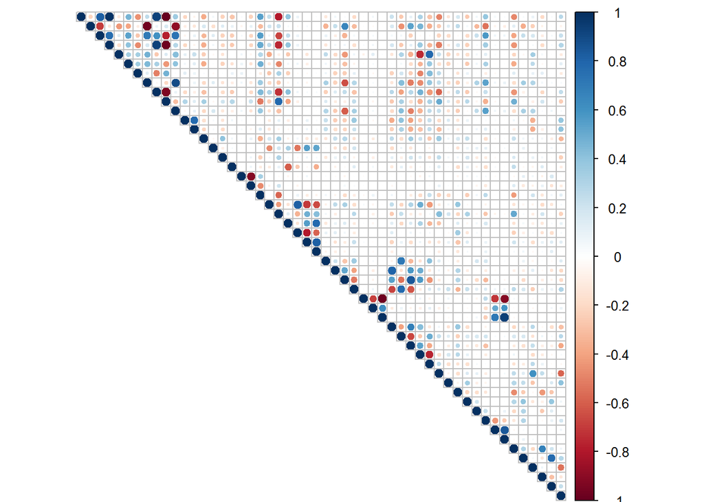

Data were divided into a training and a testing dataset (proportion 80/20). Training data was used to train 3 different algorithms which were used predict the *classe* variable. The 3 selected algorithms were: 1. A Linear Discriminant Analysis with PCA pre-processing 2. A Linear Discriminant Analysis without PCA pre-processing 3. A boosting algorithm

The 3 algorithms were selected based on data structure. Some predictors are highly correlated and reducing the number of predictors might be a good solution (method 1). Moreover **LDA** is a very powerful approach when the response variable is multi-class (method 2). On the other side a method which weight and add all the predictors (especially when these are weak) might be more useful than reducing the number of predictors (method 3).

As regards cross-validation, because of the data size and following what suggested by Kim (Estimating classification error rate: Repeated cross-validation, repeated hold-out and bootstrap, Computational Statistics & Data Analysis, Volume 53, Issue 11, 1 September 2009, Pages 37353745), a 10-fold CV scheme repeated 3 times was used.

# Results - Training

The percentage of the 5 different classes in the training dataset can be observed in the following figure.

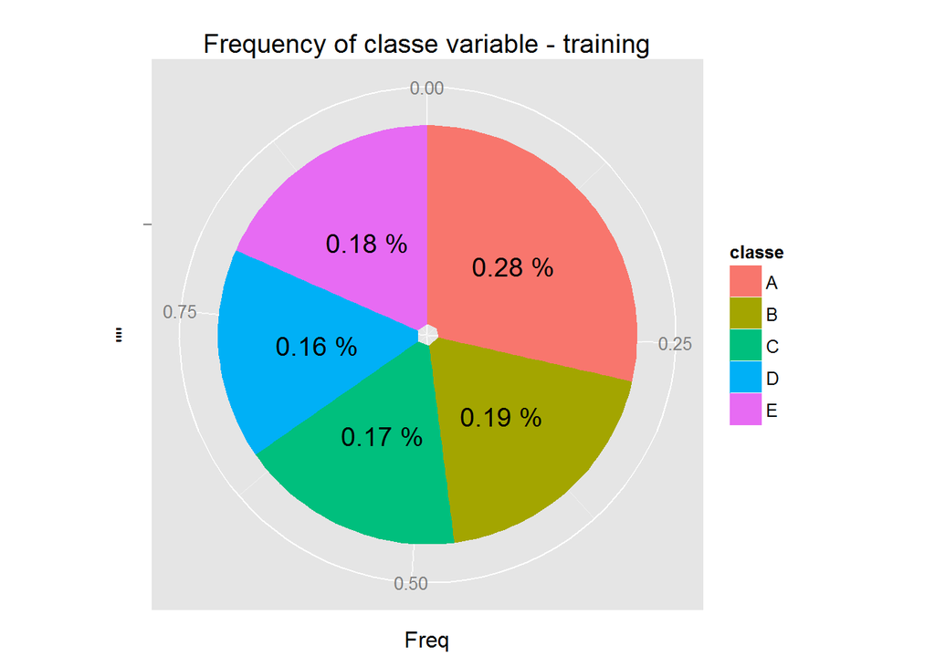

Class A (i.e., exercise correctly executed) is the most frequent, with nearly a 30 % frequency.

The accuracy obtained by the CV process was 0.5249, 0.7175 and 0.9667 for the Linear Discriminant Analysis with PCA pre-processing, the Linear Discriminant Analysis without PCA pre-processing and the boosting algorithm, respectively.

The latter algorithm showed the best results over all parameters

```r
cm.GBM
```

```
## Confusion Matrix and Statistics
##
##           Reference
## Prediction    A    B    C    D    E
##          A 1075   14    4    0    1
##          B   26  700   16    1    0
##          C    0   18  646    4    2
##          D    0    3   14  606    6
##          E    0    6    5    8  686
##
## Overall Statistics
##
##                Accuracy : 0.967
##                  95% CI : (0.961, 0.972)
##     No Information Rate : 0.287
##     P-Value [Acc > NIR] : <2e-16
##
##                   Kappa : 0.958
##  Mcnemar's Test P-Value : NA
##
## Statistics by Class:
##
##                      Class: A Class: B Class: C Class: D Class: E
## Sensitivity             0.976    0.945    0.943    0.979    0.987
## Specificity             0.993    0.986    0.992    0.993    0.994
## Pos Pred Value          0.983    0.942    0.964    0.963    0.973
## Neg Pred Value          0.991    0.987    0.988    0.996    0.997
## Prevalence              0.287    0.193    0.178    0.161    0.181
## Detection Rate          0.280    0.182    0.168    0.158    0.179
## Detection Prevalence    0.285    0.193    0.174    0.164    0.184
## Balanced Accuracy       0.985    0.965    0.968    0.986    0.991
```

# Testing

Estimates obtained from boosting algorithm were used to predict 20 unknown records. Results are as follows:

|  | X | user_name | pred_classe |
| --- | --- | --- | --- |
| 1 | 1 | pedro | B |
| 2 | 2 | jeremy | A |
| 3 | 3 | jeremy | B |
| 4 | 4 | adelmo | A |
| 5 | 5 | eurico | A |
| 6 | 6 | jeremy | E |
| 7 | 7 | jeremy | D |
| 8 | 8 | jeremy | B |
| 9 | 9 | carlitos | A |
| 10 | 10 | charles | A |
| 11 | 11 | carlitos | B |
| 12 | 12 | jeremy | C |
| 13 | 13 | eurico | B |
| 14 | 14 | jeremy | A |
| 15 | 15 | jeremy | E |
| 16 | 16 | eurico | E |
| 17 | 17 | pedro | A |
| 18 | 18 | carlitos | B |
| 19 | 19 | pedro | B |
| 20 | 20 | eurico | B |